# Stat388Project

Stephen Vosburgh, Elijah Wooten, Akhil Ghosh

12/14/2021

# Introduction

An AirBNB, otherwise known as Air Bed and Breakfast, is a unique service that allows property owners anywhere in the world to rent out their property to travelers in search of a place to stay. Rather than worry about booking an expensive hotel with many rooms for each guest, an AirBNB can be a convenient alternative, as guests can book an entire house, a private room, or a shared room. AirBNBs are located nearly everywhere in the United States, but one of the main places where they can be found is in New York City, as this is one of the most popular cities in the country. Although this unique service can be a great alternative to a hotel, the prices of these AirBNBs may vary based on its characteristics. Things such as the room type, location, and amount of nights can drastically affect the price of an AirBNB, especially in a major city such as New York City. This project is looking to be able to predict the price of an AirBNB in New York City based on its characteristics.

# Methods

## EDA and Data Clean

To begin the analysis, an exploratory data analysis was conducted. Each variable within the data set was analyzed to make initial hypotheses and access their usability. The variables of ‘id’, ‘name’, ‘host_id’, ‘last_review’, and ‘last_review’ were first analyzed for their unique values. For each of these variables, nearly each observation had its own unique categorical level, as the output generated over 1000 unique observations. There also appears to be many NA values for these variables, which would be extremely difficult to impute, as these variables are so unique. These variables appeared to be insignificant anyways, as they appeared to have been used to organize the data set, meaning that they would not be useful for predicting price. Therefore, these variables were omitted from the generated models later in the report. The variable of ‘room type’ was next analyzed by generating a bar graph to visualize its distribution. It appeared that ‘Entire home/apt’ and ‘private room’ each had over 10,000 observations, while ‘shared room’ barely had any observations in comparison to the previous two. This was extremely interesting, as ‘Entire home/apt’ and ‘private room’ would most likely lead to a more expensive price, meaning that this variable is most likely extremely useful in predicting price. This variable was then transformed into a factor variable, as this is much more useful for analysis. Next, the variable of ‘neighborhood group’ was analyzed by once again generating a bar graph to view its distribution. It appeared that ‘Brooklyn’ and ‘Manhattan’ included most observations, while ‘Staten Island’, ‘Bronx’, and ‘Queens’ did not include many observations. This is very interesting, as different neighborhoods in New York City have differing price ranges. This variable was also transformed into a factor, as this would be more beneficial for analysis. The variables of longitude and latitude were then analyzed utilizing the summary function and boxplots. The distributions for both of these variables appeared to be extremely condense, as both of their maximum and minimum values were within 0.5 of each other. This is very interesting, as the observations may belong in different neighborhoods, but are extremely close from a latitude and longitude perspective. Next, the variable of ‘minimum nights’ was analyzed utilizing the summary function and generating a boxplot. The average minimum nights was 7.056, but the boxplot appeared to show many outliers, some ranging up until 1250 nights. This was very interesting, as the longer you stay, the more expensive it would be. The variable of ‘number of reviews’ was next analyzed in the same way. Both the boxplot and summary function displayed a wide range of observations, ranging from 0 to 650, while the average was around 23. The variable of ‘availability_365’ also displayed a large distribution that was much less, showing that the different properties’ availabilities span over the entire year. For the variables of ‘reviews_per_month’ and ‘calculated_host_listings_count’, both the boxplots and summary functions also display an extremely skewed distribution, emphasizing that these variables span over a large range. From there, the variable of ‘reviews_per month’ was further examined. When analyzing this variable, there appeared to be 7008 missing values in the training data set. Since it was numeric, MICE imputation with 5 iterations was utilized to impute the missing values for this variable. There were also 3044 missing values for this variable in the test data set. MICE was once again utilized to impute those values.

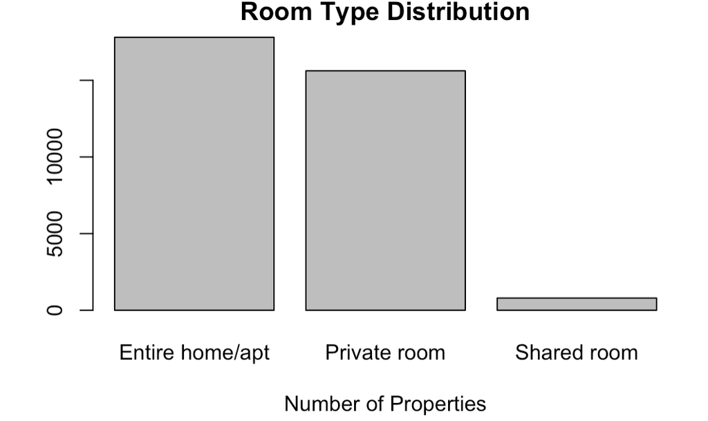

```r
knitr::include_graphics("Screen Shot 2021-12-14 at 10.25.57 PM.png")
```

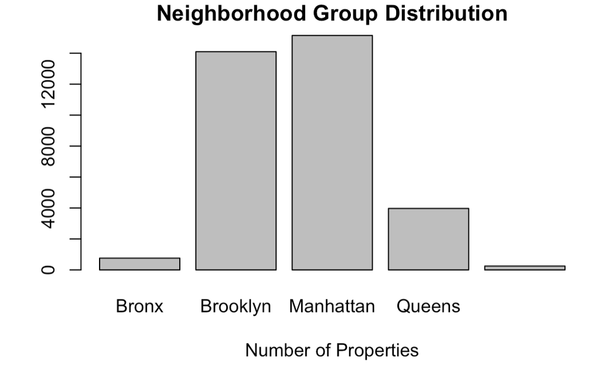

```r
knitr::include_graphics("Screen Shot 2021-12-14 at 10.33.37 PM.png")
```

## Methods for Analysis

To begin the analysis, a linear model was generated to predict price that included the variables of ‘neighbourhood_group’, ‘neighbourhood’, ‘latitude’, ‘longitude’, ‘room_type’, ‘minimum_nights’, ‘number_of_reviews’, ‘reviews_per_month’, ‘calculated_host_listings_count’, and ‘availability_365’. From there, an anova test was conducted to see which variables appeared to be significant in the general linear model. Next, a reduced linear model was created that only included the significant variables from the first linear model. This model was then submitted as the first set of predictions to understand the baseline score of having a linear model. Next, a LASSO model was created to help with variable selection to predict the price of the AirBNB. Once again, this included the variables of ‘neighbourhood_group’, ‘neighbourhood’, ‘latitude’, ‘longitude’, ‘room_type’, ‘minimum_nights’, ‘number_of_reviews’, ‘reviews_per_month’, ‘calculated_host_listings_count’, and ‘availability_365’. This method is extremely useful, as it takes ridge regression and other methods a step further by conducting variable selection. In order to conduct the LASSO model, the ideal value for lambda would make the model perform the best. To find the best lamda, cross validation was conducted by plotting the values and selecting the minimum value for lambda. From there, the method of Random Forests was then utilized to predict price. The variables included in this analysis once again included ‘neighbourhood_group’, ‘neighbourhood’, ‘latitude’, ‘longitude’, ‘room_type’, ‘minimum_nights’, ‘number_of_reviews’, ‘reviews_per_month’, ‘calculated_host_listings_count’, and ‘availability_365’ Three different random forests were generated, each with a different number of trees. Each random forest was then analyzed and each was submitted as its own set of predictions. The results of these analyses are in the following section of this report.

# Analysis

## Linear Models

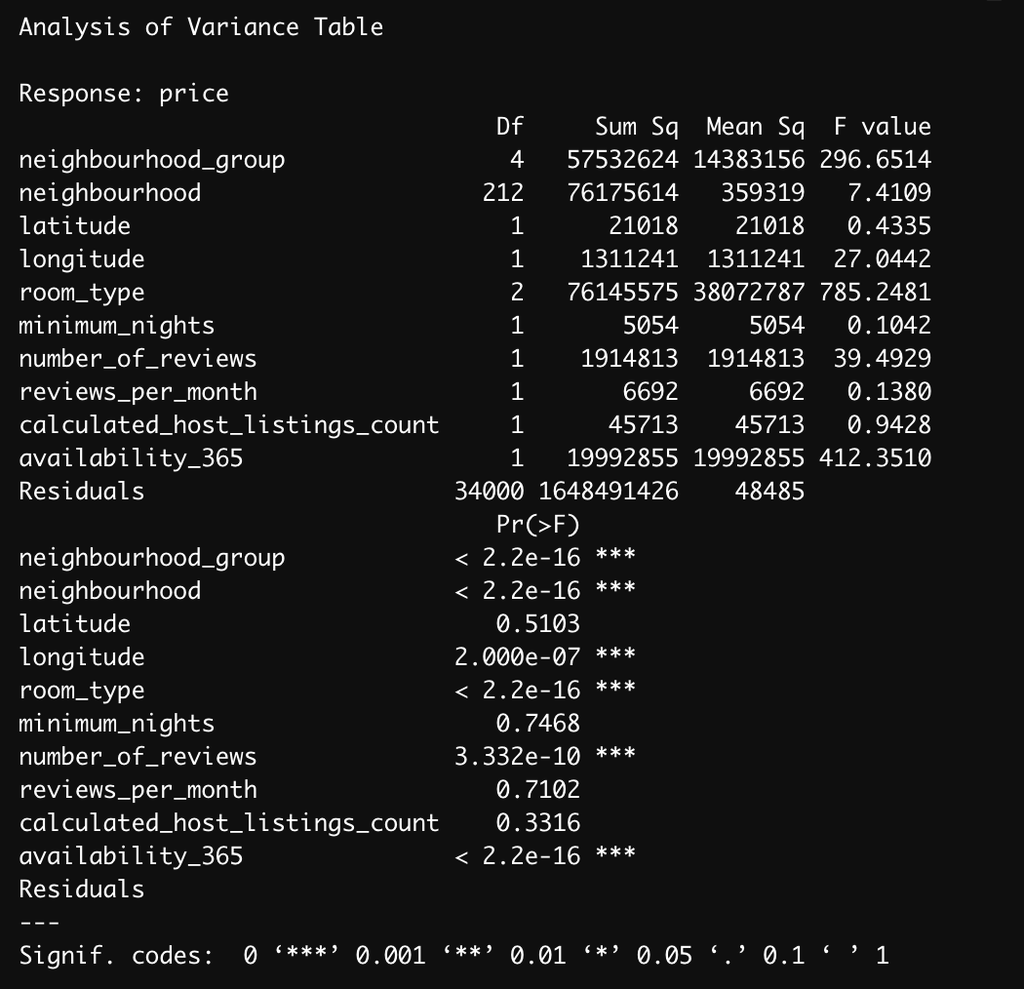

```r
knitr::include_graphics("Screen Shot 2021-12-14 at 10.36.28 PM.png")
```

ANOVA of full linear model

## LASSO

Next, the LASSO method was conducted for variable selection to help predict the price of an AirBNB in New York City. The variables that were considered included ‘neighbourhood_group’, ‘neighbourhood’, ‘latitude’, ‘longitude’, ‘room_type’, ‘minimum_nights’, ‘number_of_reviews’, ‘reviews_per_month’, ‘calculated_host_listings_count’, and ‘availability_365’. To conduct the LASSO model in he correct fashion, the ideal lambda value must be calculated through cross validation. This was conducted by utilizing the ‘cv.glmnet’ function in R and choosing the minimum lambda value on the plot of the log(lambda) vs. the MSE. Therefore, the best lambda value was 0.607005, which is shown from the minimum value on the graph. From there, the LASSO model was constructed utilizing this optimized lambda value. The coefficients of this model were then printed to understand which variables it chose to be significant in predicting price. From the printed coefficients, it appears that the variables of ‘neighborhood group’, ‘room type’, ‘minimum nights’, ‘number of reviews’, ‘reviews per month’, ‘calculated_host_listings_count’, ‘availability_365’, and ‘longitude’ are significant in predicting the price. The variable of neighborhood seemed to be converted to a dummy variable, with each neighborhood being its own separate predictor. Within these variables, although many neighborhoods were insignificant, the majority of them were, meaning it should be included in the significant variables. Although longitude was significant, it appeared that latitude was not significant in predicting price, which was extremely interesting. Therefore, the significant variables selected from the LASSO Model included ‘neighborhood group’, ‘neighborhood’, ‘room type’, ‘minimum nights’, ‘number of reviews’, ‘reviews per month’, ‘calculated_host_listings_count’, ‘availability_365’, and ‘longitude’.

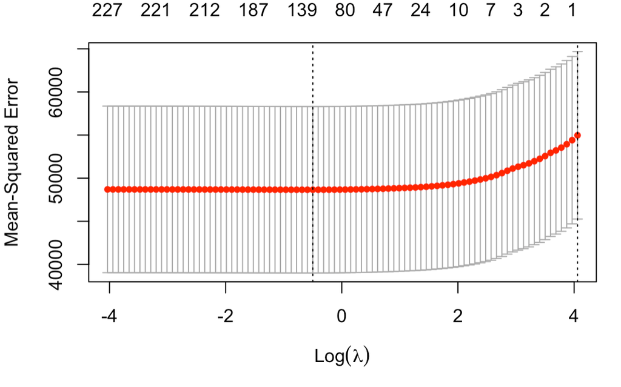

```r
knitr::include_graphics("Screen Shot 2021-12-14 at 10.39.10 PM.png")
```

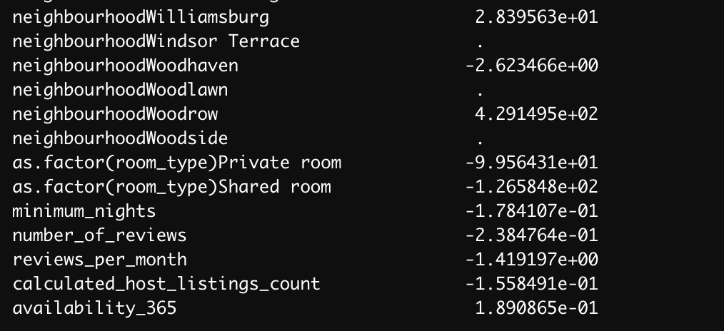

```r
knitr::include_graphics("Screen Shot 2021-12-14 at 10.39.43 PM.png")
```

Some significant coeffients from LASSO